# Star Asia Trading - Prediction of overhead costs

Accounting Analytics Capstone Project

Balkis, Jerome Jeevan Naidu, Gavin Ong Ze Kai, Kenneth Tan Yan Hau

2019-03-25

```r
# Load libraries
library(openxlsx) # to load xlsx files
library(tidyverse) # general library for data cleaning
library(lubridate) # for date formatting
library(zoo) # for date formatting
library(caret) # for cross-validated models
library(glmnet) # for LASSO (Least Absolute Shrinkage and Selection Operator)
library(randomForest) # use varImp in conjunction with caret randomForest output
library(car) # for finding variance inflation factor to deal with multicollinearity
library(coefplot)
```

# 1. Load Files

```r
dailyVar <- read.xlsx("6. SAT Cleaned_Data Compiled 28 Feb 19 v4.xlsx", sheet = 1,
                    colNames = TRUE, startRow = 3, detectDates = TRUE, cols = 2:26)
                    # sheet = 1 contains daily variables from
OHcost <- read.xlsx("6. SAT Cleaned_Data Compiled 28 Feb 19 v4.xlsx", sheet = 3,
                    colNames = TRUE, detectDates = TRUE)
                    # sheet = 3 contains monthly overhead figures from fin data
```

# 2. Data Cleaning

```r
# Cleaning and pre-processing

colnames(OHcost)[1] <- "Date" # Rename "X1" column to "Date
OHcost$YearMon <- as.yearmon(OHcost$Date) # Convert OHCost$Date to year-mon format
dailyVar$Working.Hours.Gross <- as.numeric(dailyVar$Working.Hours.Gross)

# Remove weekends from data (no work) and no output days
dailyVar_WD <- dailyVar[which(weekdays(dailyVar$Date)
         %in% c('Monday','Tuesday', 'Wednesday', 'Thursday', 'Friday')), ]

dailyVar_operating <- dailyVar_WD %>%
  filter(dailyVar_WD$Output_Cut_Sew > 0)

# Change NAs to 0s
dailyVar_operating[is.na(dailyVar_operating)] <- 0
```

# 3. Calculation of derived variables

```r
# Calculate derived variables

dailyVar_operating$RFT_Cut <-
  with(dailyVar_operating, (Output_Cut_Sew - Defect_Cut)/Output_Cut_Sew)
dailyVar_operating$RFT_Sew <-
  with(dailyVar_operating, (Output_Cut_Sew - Defect_Sew)/Output_Cut_Sew)
dailyVar_operating$RFT_Assembly <-
  with(dailyVar_operating, (Output_Assembly - Defect_Assembly)/Output_Assembly)
dailyVar_operating$RFT_ReInspection <-
  with(dailyVar_operating, (Pass_Reinspection - Defect_ReInspection)/Output_Assembly)
dailyVar_operating$PPH.Actual.Gross<-
  with(dailyVar_operating, Output_Assembly / Man.Hours.Gross)
dailyVar_operating$Downtime.Percentage <-
  with(dailyVar_operating, Downtime_Seconds / Operating_Time_Sec)

# Split variables that should be summed - e.g. Output, Defect
sum_variables <- subset(dailyVar_operating, select = -c(Target.BEP,
                                      EOLR.Target, EOLR.Gross,
                                     Working.Hours.Gross, RFT_Cut,
                                     RFT_Sew,
                                     RFT_Assembly,
                                     RFT_ReInspection,
                                     PPH.Actual.Gross,
                                     Downtime.Percentage))

# Split variables that are ratios in nature
avg_variables <- dailyVar_operating[, c("Plant", "Cell", "Date",
                                  "Target.BEP", "EOLR.Target", "EOLR.Gross",
                                  "Working.Hours.Gross", "RFT_Cut",
                                  "RFT_Sew",
                                  "RFT_Assembly",
                                  "RFT_ReInspection",
                                  "PPH.Actual.Gross",
                                  "Downtime.Percentage")]

# Group summed variables into respective year-month and form dataframe
grouped_monthlySumVar <- sum_variables %>%
  group_by(Plant, Cell, as.yearmon(Date)) %>%
  summarise_all(funs(sum))

# Group averaged variables into respective year-month and form dataframe
grouped_monthlyAvgVar <- avg_variables %>%
  group_by(Plant, Cell, as.yearmon(Date)) %>%
  summarise_all(funs(mean))

# merge summed variables and averaged variables
df <- merge(grouped_monthlySumVar, grouped_monthlyAvgVar,
            by = c("Plant", "Cell", "as.yearmon(Date)"))

df2 <- merge(df, OHcost, by.x = "as.yearmon(Date)", by.y = "YearMon")

# Rename as.yearmon(date) to Year-Month
colnames(df2)[which(names(df2) == "as.yearmon(Date)")] <- "Year-Month"


# NaN, Inf to 0s - because some ratios evaluate to NaN or Inf
df2 <- df2 %>%
  mutate_if(is.numeric, funs(replace(., !is.finite(.), 0)))



# Multiply OH/Pair by 1000000 to convert to rupiah
df2 <- df2 %>%
  mutate(rupiah = `OH/Pair` * 1000000)


# Sort df2
df2 <- df2[order(df2$Plant, df2$Cell, df2$`Year-Month`),]


# Split into test and train data

df2_train <- df2 %>% filter(`Year-Month` < "Jun 2018")
df2_test <- df2 %>% filter(`Year-Month` >= "Jun 2018")
```

# 4. First Linear Regression model

```r
# Variables setup for model

variables_1 <- as.formula("rupiah ~
                           Output_Assembly +
                           Output_Cut_Sew +
                           Man.Power +
                           Man.Hours.Gross +
                           Defect_Cut +
                           Defect_Sew +
                           Defect_Assembly +
                           QtyDowntime +
                           Downtime_Seconds +
                           Operating_Time_Sec +
                           Target.BEP +
                           EOLR.Target +
                           EOLR.Gross +
                           Working.Hours.Gross +
                           RFT_Cut+
                           RFT_Sew +
                           RFT_Assembly +
                           RFT_ReInspection +
                           PPH.Actual.Gross +
                           Downtime.Percentage")



# Linear regression
lm <- lm(variables_1, data = df2_train)

# Multicollinearity check
vif(lm)
```

```
##     Output_Assembly      Output_Cut_Sew           Man.Power
##           43.922734           37.008004           19.214634
##     Man.Hours.Gross          Defect_Cut          Defect_Sew
##           30.724835            4.842771            9.093286
##     Defect_Assembly         QtyDowntime    Downtime_Seconds
##            2.286524            2.514310            8.562281
##  Operating_Time_Sec          Target.BEP         EOLR.Target
##            1.632888            1.356564            1.961382
##          EOLR.Gross Working.Hours.Gross             RFT_Cut
##            4.519693            5.807690            5.140264
##             RFT_Sew        RFT_Assembly    RFT_ReInspection
##            9.399309            1.493204            2.148633
##    PPH.Actual.Gross Downtime.Percentage
##            2.445257            6.399493
```

```r
# Predict testing data
pred1 <- predict(lm, newdata = df2)

df2_test_predictedlm <- cbind(df2, pred1)

df2_test_average_lm <- df2_test_predictedlm %>%
  group_by(`Year-Month`) %>%
  summarise(PredictedOH = mean(pred1))

# Total MAE
df2_actual_vs_pred_lm <- cbind(df2[1:22,], df2_test_average_lm)

error_1 <- df2_actual_vs_pred_lm$PredictedOH - df2_actual_vs_pred_lm$rupiah

MAE_lm_1 <- mean(abs(error_1))
MAE_lm_1
```

```
## [1] 18229.26
```

```r
# Out of sample MAE

error_1 <- df2_actual_vs_pred_lm$PredictedOH[18:22] -     df2_actual_vs_pred_lm$rupiah[18:22]

MAE_lm_1 <- mean(abs(error_1))
MAE_lm_1
```

```
## [1] 22097.71
```

*What does the Linear Regression model do?*:

Attempt to find best fit line and explain the economic relationship between dependent variables and independent variable.

*Model Results and Interpretation*:

However, there are certain dependent variables with high variance inflation factors. This means that these variables are highly correlated with one another and unnecessarily adds weight to variables that might possibly be similar. We will remove these factors in the second LR model.

# 5. Second Linear Regression model without high VIF variables and non-significant variables

```r
variables_2 <- as.formula("rupiah ~
                           Man.Hours.Gross +
                           Operating_Time_Sec +
                           Target.BEP +
                           Defect_Assembly +
                           EOLR.Gross +
                           Working.Hours.Gross +
                           PPH.Actual.Gross +
                           Downtime.Percentage")

# Linear regression
lm2 <- lm(variables_2, data = df2_train)

summary(lm2)
```

```
##
## Call:
## lm(formula = variables_2, data = df2_train)
##
## Residuals:
##    Min     1Q Median     3Q    Max
## -42780 -19072  -3361  14351  63590
##
## Coefficients:
##                       Estimate Std. Error t value Pr(>|t|)
## (Intercept)          2.371e+05  3.029e+04   7.830 4.58e-13 ***
## Man.Hours.Gross     -8.933e-01  4.805e-01  -1.859  0.06473 .
## Operating_Time_Sec  -7.513e-03  4.185e-03  -1.795  0.07435 .
## Target.BEP          -3.310e+04  7.935e+03  -4.172 4.77e-05 ***
## Defect_Assembly      6.692e+00  2.421e+00   2.764  0.00633 **
## EOLR.Gross          -1.503e+02  9.456e+01  -1.590  0.11373
## Working.Hours.Gross -8.205e+03  3.849e+03  -2.132  0.03443 *
## PPH.Actual.Gross    -6.856e+03  1.052e+04  -0.652  0.51537
## Downtime.Percentage  1.273e+05  2.284e+05   0.557  0.57795
## ---
## Signif. codes:  0 '***' 0.001 '**' 0.01 '*' 0.05 '.' 0.1 ' ' 1
##
## Residual standard error: 25290 on 174 degrees of freedom
## Multiple R-squared:  0.203,  Adjusted R-squared:  0.1664
## F-statistic: 5.541 on 8 and 174 DF,  p-value: 3.004e-06
```

```r
# Check vif for multicollinearity
vif(lm2)
```

```
##     Man.Hours.Gross  Operating_Time_Sec          Target.BEP
##            2.483461            1.263606            1.267450
##     Defect_Assembly          EOLR.Gross Working.Hours.Gross
##            1.694076            1.911784            2.406964
##    PPH.Actual.Gross Downtime.Percentage
##            1.827704            1.062871
```

```r
pred2 <- predict(lm2, newdata = df2)

df2_test_predictedlm2 <- cbind(df2, pred2)

df2_test_average_lm2 <- df2_test_predictedlm2 %>%
  group_by(`Year-Month`) %>%
  summarise(PredictedOH = mean(pred2))

# Total MAE
df2_actual_vs_pred_lm2 <- cbind(df2[1:22,], df2_test_average_lm2)

error_2 <- df2_actual_vs_pred_lm2$PredictedOH - df2_actual_vs_pred_lm2$rupiah

MAE_lm_2 <- mean(abs(error_2))
MAE_lm_2
```

```
## [1] 17869.84
```

```r
# Out of sample MAE

error_2 <- df2_actual_vs_pred_lm2$PredictedOH[18:22] -     df2_actual_vs_pred_lm2$rupiah[18:22]


MAE_lm_2 <- mean(abs(error_2))
MAE_lm_2
```

```
## [1] 15804.55
```

*Results*:

Lower out-of-sample MAE than first LR model. It seems that the removal of correlated variables works. This also means that less input is required and there might be less overfitting of variables.

# 6. LASSO model to minimise number of variables

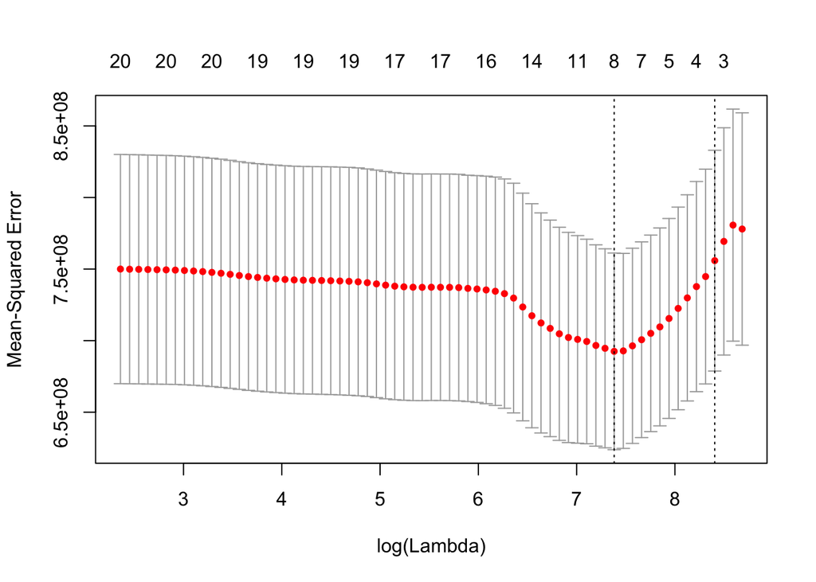

```r
# LASSO

# Set up matrixes for LASSO since it only accepts matrices
# Model matrix sets up dummy variables for categorical variables
# Model frame returns a data.frame with variables needed to use the formula 'variables_1'

x <- model.matrix(variables_1, data = df2_train)[,-1]
y <- model.frame(variables_1, data = df2_train)[, "rupiah"]

# Set.seed to ensure reproducibility

set.seed(466846)

# cv.glmnet refers to a cross-validated LASSO                                      model when alpha = 1

LASSO <- cv.glmnet(y = y,
                  x = x,
                  family = "gaussian",
                  alpha = 1,
                  type.measure = "mse", nfolds = 1000)



plot(LASSO)
```

```r
coef(LASSO, s= "lambda.min") # shows coefficients of LASSO, including less                                        significant ones
```

```
## 21 x 1 sparse Matrix of class "dgCMatrix"
##                                 1
## (Intercept)          1.942276e+05
## Output_Assembly      .
## Output_Cut_Sew       .
## Man.Power            .
## Man.Hours.Gross     -2.949902e-01
## Defect_Cut           .
## Defect_Sew          -7.088858e+00
## Defect_Assembly      1.177171e+00
## QtyDowntime          .
## Downtime_Seconds     .
## Operating_Time_Sec  -1.639357e-03
## Target.BEP          -2.457086e+04
## EOLR.Target          .
## EOLR.Gross          -1.295530e+02
## Working.Hours.Gross -6.643913e+03
## RFT_Cut              .
## RFT_Sew              .
## RFT_Assembly         .
## RFT_ReInspection     2.378664e+03
## PPH.Actual.Gross     .
## Downtime.Percentage  .
```

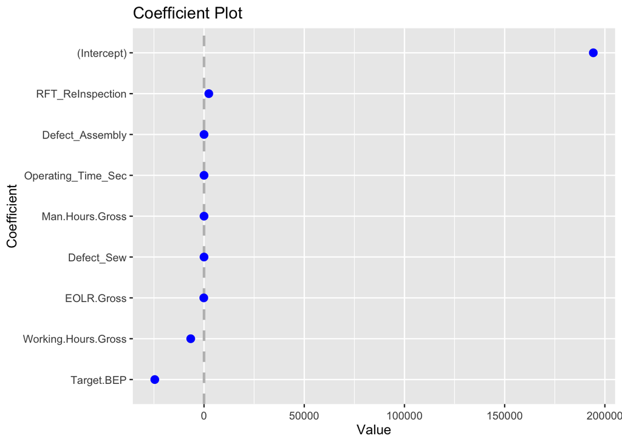

```r
coefplot(LASSO, lambda="lambda.min", sort = 'magnitude') # plot for coefs
```

```r
# Finding RMSE - error metric for comparison

xvals <- model.matrix(variables_1, data=df2)[,-1]
yvals <- model.frame(variables_1, data=df2)[,"rupiah"]

pred_LASSO <- predict(LASSO, xvals, s = "lambda.min", type = "response")



df2_test_predicted_LASSO <- cbind(df2, pred_LASSO)

colnames(df2_test_predicted_LASSO)[which(names(df2_test_predicted_LASSO) == "1")] <- "pred_LASSO"

df2_test_average_LASSO <- df2_test_predicted_LASSO %>%
  group_by(`Year-Month`) %>%
  summarise(PredictedOH = mean(pred_LASSO))

# Total MAE
df2_actual_vs_pred_LASSO <- cbind(df2[1:22,], df2_test_average_LASSO)

error_LASSO <- df2_actual_vs_pred_LASSO$PredictedOH - df2_actual_vs_pred_LASSO$rupiah

MAE_LASSO <- mean(abs(error_LASSO))
MAE_LASSO
```

```
## [1] 20925.03
```

```r
# Out of sample MAE

error_LASSO <- df2_actual_vs_pred_LASSO$PredictedOH[18:22] -     df2_actual_vs_pred_LASSO$rupiah[18:22]

MAE_LASSO <- mean(abs(error_LASSO))
MAE_LASSO
```

```
## [1] 26915.22
```

*What does the LASSO model do?*:

LASSO stands for Least Absolute Shrinkage and Selection Operator and it has two main functions: shrinkage and selection. The shrinkage function is achieved because the algorithm penalises large coefficient values and attempts to shrinks them, thereby achieving a stabler model for predictions. The selection function is achieved geometrically when less useful variables are eliminated from the equation completely.

There are many advantages in using LASSO method, first of all it can provide a very good prediction accuracy, because shrinking and removing the coefficients can reduce variance without a substantial increase of the bias, this is especially useful when you have a small number of observation and a large number of features.

Moreover the LASSO helps to increase the model interpretability by eliminating irrelevant variables that are not associated with the response variable, this way also overfitting is reduced.

*Model Results and Interpretation*:

The out-of-sample MAE for this model is 26915.22.

*Limitations of this model*:

1. No p-values on coefficients
2. Generally worse in sample performance
3. Sometimes worse out of sample performance (short run) BUT: predictions will be more stable

# 7. Random Forest model

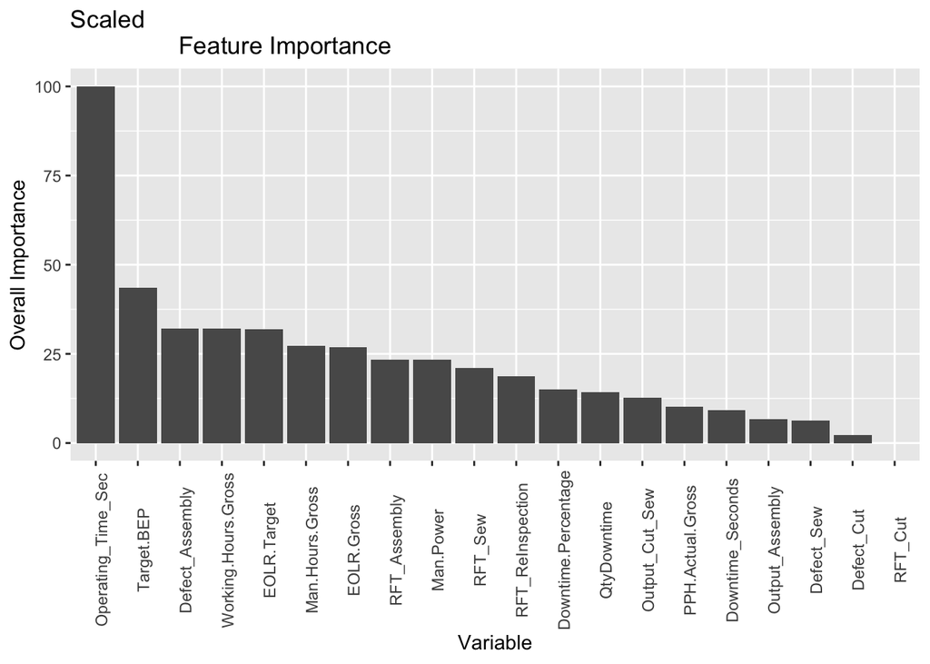

```r
# caret random forest
set.seed(100)
control <- trainControl(method="repeatedcv", number = 10, repeats = 10)
RF <- train(variables_1, data = df2_train, method = "rf", preProcess= c("scale",
               "center"), trControl = control, importance = T)

importance <- varImp(RF)
imp_df2 <- importance$importance
imp_df2$group <- rownames(imp_df2)

imp_df2 %>%
  ggplot(aes(x = reorder(group, -Overall), y = Overall), size = 2) +
           geom_bar(stat = "identity") + theme(axis.text.x = element_text
                                               (vjust = 1, angle = 90)) +
           labs(x = "Variable", y = "Overall Importance", title = "Scaled
                Feature Importance")
```

```r
pred_RF <- predict(RF, newdata = df2)

df2_test_predicted_RF <- cbind(df2, pred_RF)

df2_test_average_RF <- df2_test_predicted_RF %>%
  group_by(`Year-Month`) %>%
  summarise(PredictedOH = mean(pred_RF))

df2_actual_vs_pred_RF <- cbind(df2[1:22,], df2_test_average_RF)

# Total MAE
error_RF <- df2_actual_vs_pred_RF$PredictedOH - df2_actual_vs_pred_RF$rupiah

MAE_RF <- mean(abs(error_RF))
MAE_RF
```

```
## [1] 10879.79
```

```r
# Out of SAMPLE MAE

error_RF <- df2_actual_vs_pred_RF$PredictedOH[18:22] - df2_actual_vs_pred_RF$rupiah[18:22]

MAE_RF <- mean(abs(error_RF))
MAE_RF
```

```
## [1] 27030.47
```

*What does the RF model do?*:

Random forests or random decision forests are an ensemble learning method for classification, regression and other tasks that operates by constructing a multitude of decision trees at training time and outputting the class that is the mode of the classes (classification) or mean prediction (regression) of the individual trees. Random decision forests correct for decision trees’ habit of overfitting to their training set.

The model also contains a method of k-fold cross validation (default, k = 10) 1. Randomly splits the data into k groups 2. Runs the algorithm on 90% of the data ( k − 1 groups) 3. Determines the best model 4. Repeat steps 2 and 3 k − 1 more times 5. Uses the best overall model across all k hold out samples

*Model Results and Interpretation*:

The out-of-sample MAE for this model is 27030.47.